# Market Basket - Bakery

**Analysis of Bakery Purchases**

We first import the necessary libraries for the market analysis.

```r
library(tidyverse)
library(knitr)
library(gridExtra)
library(arules)
library(arulesViz)
```

Using read.transactions() from the arules package, we can then create a class combining the transaction IDs and purchased item from the comma-separated data file.

```r
transactions <- read.transactions("./BreadBasket_DMS.csv",
                                  format = "single",
                                  cols = c(3,4),
                                  sep = ",",
                                  rm.duplicates = TRUE)
```

We can first check the general frequency of items purchased in general, without looking at their associations yet.

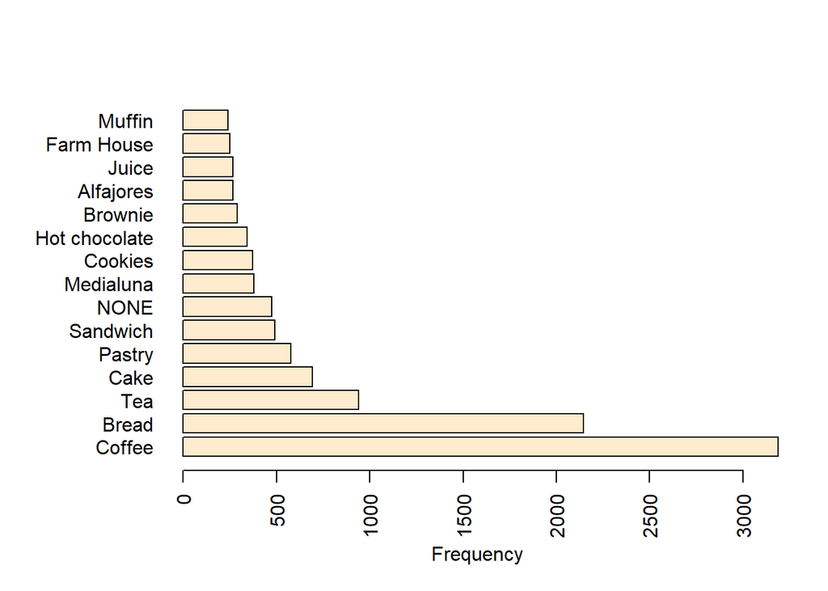

```r
itemFrequencyPlot(transactions,
                  type = "absolute",
                  topN = 15,
                  xlab = "Frequency",
                  horiz = T,
                  lwd = 1,
                  col = "blanchedAlmond")
```

We then use the apriori algorithm to get our rules. The function takes a support and confidence limit in a parameter list, pruning any rules that fall below that threshold per iteration. Target tells the function what type of association we want.

```r
parameterList <- list(support = 0.01, confidence = 0.5, target = "rules")
rules <- apriori(transactions, parameter = parameterList)
```

```
## Apriori
##
## Parameter specification:
##  confidence minval smax arem  aval originalSupport maxtime support minlen
##         0.5    0.1    1 none FALSE            TRUE       5    0.01      1
##  maxlen target   ext
##      10  rules FALSE
##
## Algorithmic control:
##  filter tree heap memopt load sort verbose
##     0.1 TRUE TRUE  FALSE TRUE    2    TRUE
##
## Absolute minimum support count: 66
##
## set item appearances ...[0 item(s)] done [0.00s].
## set transactions ...[104 item(s), 6614 transaction(s)] done [0.00s].
## sorting and recoding items ... [30 item(s)] done [0.00s].
## creating transaction tree ... done [0.00s].
## checking subsets of size 1 2 3 done [0.00s].
## writing ... [13 rule(s)] done [0.00s].
## creating S4 object  ... done [0.00s].
```

```r
print(length(rules))
```

```
## [1] 13
```

It is not yet clear what support and confidence threshold values we want for the best result, so we can try out many values and see what gives us a reasonable amount of meaningful rules. In the sample function above, we got 13 rules with a confidence of above 50%. We can use a for loop to try out different values and see how many meaningful rules we get:

We can look at our four new vectors, telling us the amount of rules found for each support and confidence level.

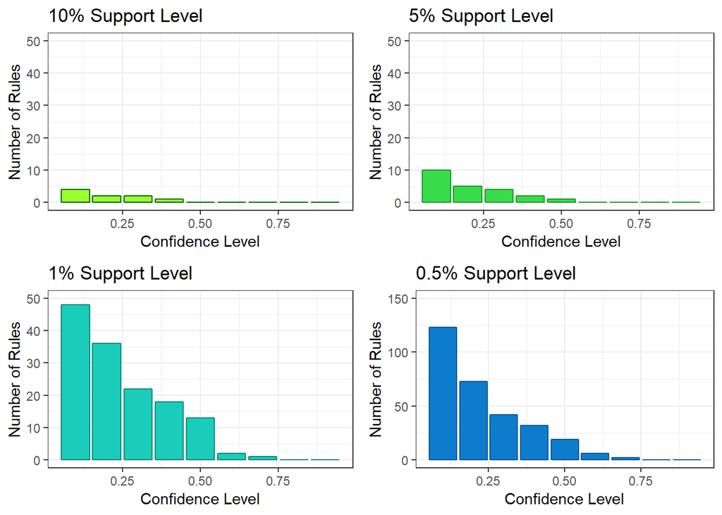

```r
plot10 <- qplot(confidenceLevels, ruleLengthForSupp10,
  xlab = "Confidence Level", main = "10% Support Level", geom = "blank") +
  geom_col(fill = c("#99FF33"), color = c("#006600")) + theme_bw() +
  scale_y_continuous(name = "Number of Rules", limits = c(0, 50))

plot5 <- qplot(confidenceLevels, ruleLengthForSupp5,
  xlab = "Confidence Level", main = "5% Support Level", geom = "blank") +
  geom_col(fill = c("#39db4b"), color = c("#199627")) + theme_bw() +
  scale_y_continuous(name = "Number of Rules", limits = c(0, 50))

plot1 <- qplot(confidenceLevels, ruleLengthForSupp1,
  xlab = "Confidence Level", main = "1% Support Level", geom = "blank") +
  geom_col(fill = c("#1accba"), color = c("#0e877a")) + theme_bw() +
  scale_y_continuous(name = "Number of Rules", limits = c(0, 50))

plot0.5 <- qplot(confidenceLevels, ruleLengthForSupp0.5,
  xlab = "Confidence Level", main = "0.5% Support Level", geom = "blank") +
  geom_col(fill = c("#0e7ccc"), color = c("#055893")) + theme_bw() +
  scale_y_continuous(name = "Number of Rules", limits = c(0, 150))

# Puts the four ggplot2 plots into a 2x2 grid
grid.arrange(plot10, plot5, plot1, plot0.5, nrow = 2)
```

Now we can see the number of rules for each support level and confidence levels. A support level of 10% prunes too many rules, and 0.5% gives too many. We want a reasonable amount with a good confidence level, so we’ll choose 1% and 50% confidence.

```r
inspect(rulesFinal)
```

```
##      lhs                 rhs      support    confidence lift     count
## [1]  {Tiffin}         => {Coffee} 0.01058361 0.5468750  1.134577  70
## [2]  {Spanish Brunch} => {Coffee} 0.01406108 0.6326531  1.312537  93
## [3]  {Scone}          => {Coffee} 0.01844572 0.5422222  1.124924 122
## [4]  {Toast}          => {Coffee} 0.02570305 0.7296137  1.513697 170
## [5]  {Alfajores}      => {Coffee} 0.02237678 0.5522388  1.145705 148
## [6]  {Juice}          => {Coffee} 0.02131842 0.5300752  1.099723 141
## [7]  {Hot chocolate}  => {Coffee} 0.02721500 0.5263158  1.091924 180
## [8]  {Medialuna}      => {Coffee} 0.03296039 0.5751979  1.193337 218
## [9]  {Cookies}        => {Coffee} 0.02978530 0.5267380  1.092800 197
## [10] {NONE}           => {Coffee} 0.04172966 0.5810526  1.205484 276
## [11] {Sandwich}       => {Coffee} 0.04233444 0.5679513  1.178303 280
## [12] {Pastry}         => {Coffee} 0.04868461 0.5590278  1.159790 322
## [13] {Cake}           => {Coffee} 0.05654672 0.5389049  1.118042 374
```

Seems like a purchase with pretty much any pastry implies a purchase of coffee. Not too surprising considering people need a liquid to pair their breakfast with.

Support tells us what percent of purchases had a purchase with those pair of items. Confidence tells us how often a purchase of the first item has actually been followed with a purchase of the second item. Lift tells us the ratio of the support of that rule to the support if both had no purchasing relationship with each other.

We can see that Toast => Coffee has 73% confidence and 1.51 lift, making it one of the strongest connections.

Let’s do a basic visualization:

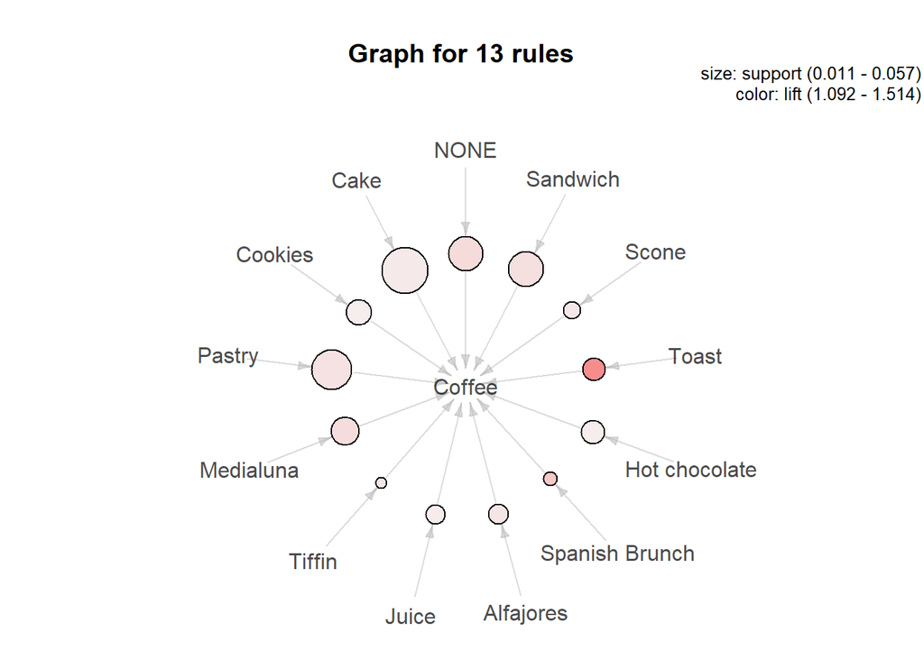

```r
plot(rulesFinal, method = "graph")
```

The “arulesViz” allows us to use the default plot() function for our visualizations.

We can also try another run with different arguments and see what rules we get. Let’s try reducing our support threshold, allowing more obscure purchases in.

```r
inspect(rulesAlt)
```

```
##      lhs                     rhs      support     confidence lift
## [1]  {Hearty & Seasonal}  => {Coffee} 0.005443000 0.5454545  1.131630
## [2]  {Jammie Dodgers}     => {Coffee} 0.007257333 0.5161290  1.070790
## [3]  {Salad}              => {Coffee} 0.007862111 0.6117647  1.269201
## [4]  {Tiffin}             => {Coffee} 0.010583611 0.5468750  1.134577
## [5]  {Spanish Brunch}     => {Coffee} 0.014061083 0.6326531  1.312537
## [6]  {Scone}              => {Coffee} 0.018445721 0.5422222  1.124924
## [7]  {Toast}              => {Coffee} 0.025703054 0.7296137  1.513697
## [8]  {Alfajores}          => {Coffee} 0.022376777 0.5522388  1.145705
## [9]  {Juice}              => {Coffee} 0.021318415 0.5300752  1.099723
## [10] {Hot chocolate}      => {Coffee} 0.027214998 0.5263158  1.091924
## [11] {Medialuna}          => {Coffee} 0.032960387 0.5751979  1.193337
## [12] {Cookies}            => {Coffee} 0.029785304 0.5267380  1.092800
## [13] {NONE}               => {Coffee} 0.041729664 0.5810526  1.205484
## [14] {Sandwich}           => {Coffee} 0.042334442 0.5679513  1.178303
```

[output cut: 25 more lines]

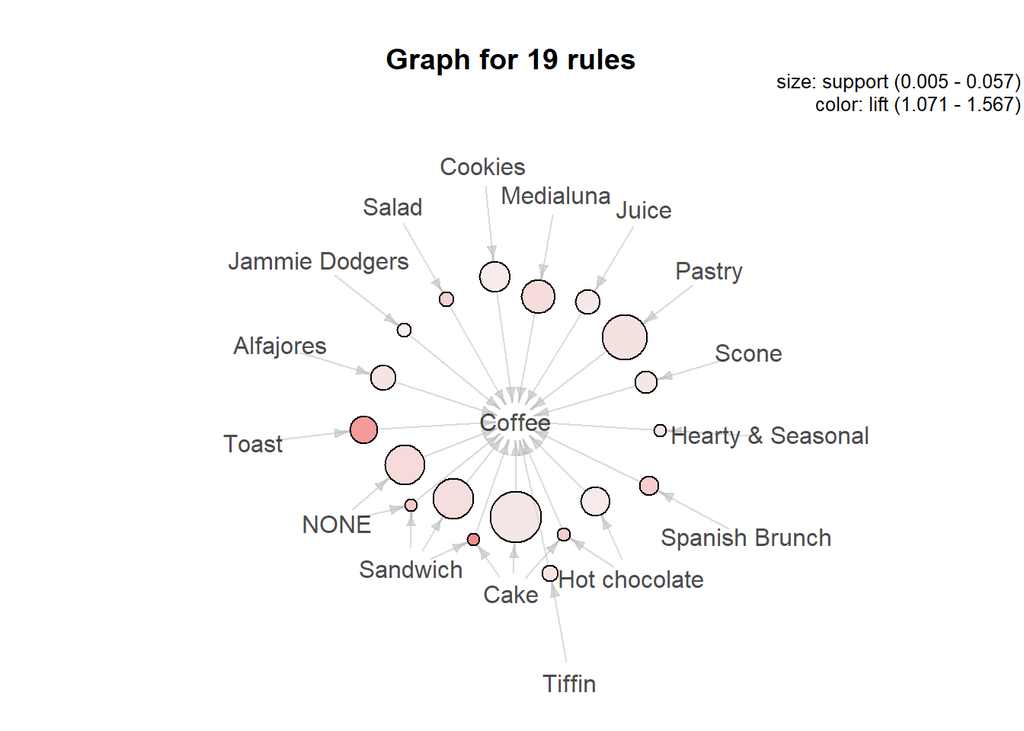

```r
plot(rulesAlt, method = "graph")
```

Now we have some sets including two items, such as { Cake, Hot Chocolate } => { Coffee }. However, since our support threshold is so low, it’s possible there are just outliars.